# NameByStateYMD

Yakovlev D.M.

2023-12-05

# USA Name Data

```r
library("tidyverse")
library("ggridges")
data <- read.csv("USA Name Data.csv")
top10 <- 10
```

Проверим популярность имён по первой букве

```r
data_by_first_letter <- data |>
  select(Name, Number, Gender)|>
  group_by(Name)|>
  mutate(Name = sapply(Name, function(x) substring(x, 1, 1)))
```

Мальчики

```r
data_male <- data_by_first_letter|>
  filter(Gender == "M")|>
  summarise(Number = sum(Number))|>
  mutate(Ratio = Number/sum(Number),
         Color = ifelse(Number >= mean(Number), "lightblue", "tomato"))
```

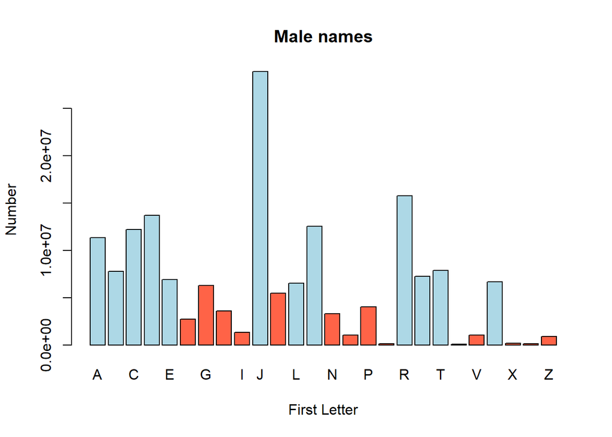

```r
barplot(data_male$Number,
        names.arg = data_male$Name,
        xlab = "First Letter",
        ylab = "Number",
        main = "Male names",
        col = data_male$Color)
```

```r
summary(data_male$Number)
```

```
##     Min.  1st Qu.   Median     Mean  3rd Qu.     Max.
##    68905  1120764  5868449  6451043  7838694 28911639
```

Девочки

```r
data_female <- data_by_first_letter|>
  filter(Gender == "F")|>
  summarise(Number = sum(Number))|>
  mutate(Ratio = Number/sum(Number),
         Color = ifelse(Number >= mean(Number), "lightblue", "tomato"))
```

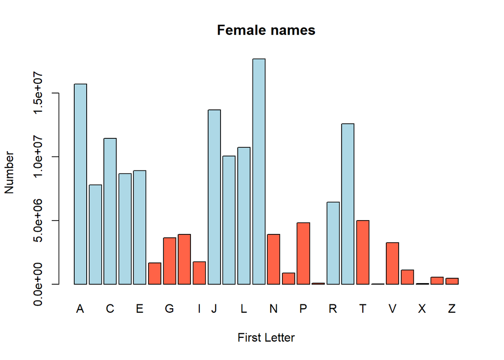

```r
barplot(data_female$Number,
        names.arg = data_female$Name,
        xlab = "First Letter",
        ylab = "Number",
        main = "Female names",
        col = data_female$Color)
```

```r
summary(data_female$Number)
```

```
##     Min.  1st Qu.   Median     Mean  3rd Qu.     Max.
##    27234  1252658  4363402  5955840  9771153 17687987
```

Все

```r
data_by_first_letter <- data_by_first_letter |>
  summarize(Number = sum(Number))|>
  mutate(Ratio = Number/sum(Number),
         Color = ifelse(Number >= mean(Number), "lightblue", "tomato"))
```

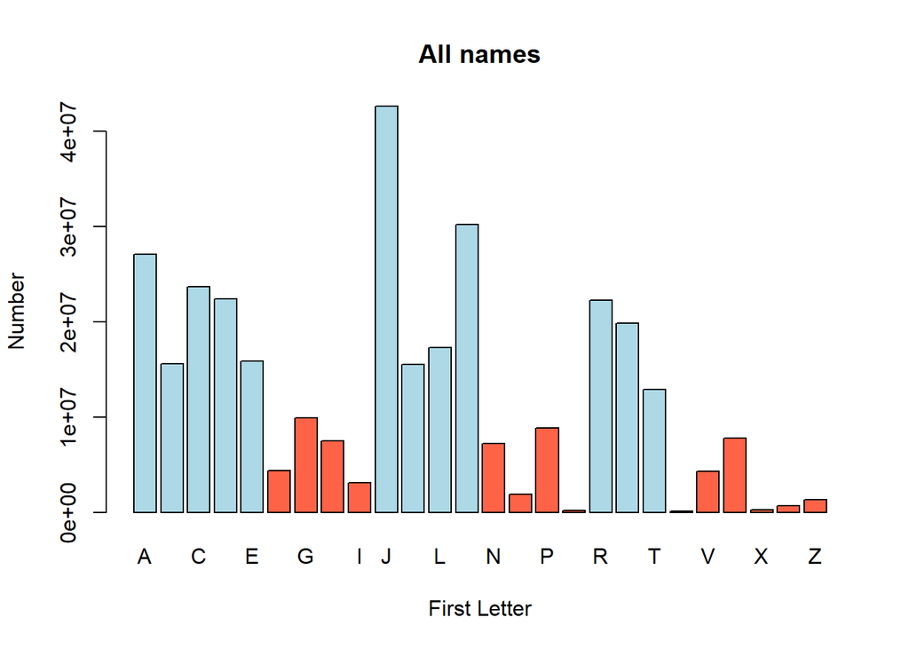

```r
barplot(data_by_first_letter$Number,
        names.arg = data_by_first_letter$Name,
        xlab = "First Letter",
        ylab = "Number",
        main = "All names",
        col = data_by_first_letter$Color)
```

Самые используемые первые буквы

```r
data_by_first_letter|>
  slice_max(order_by=Number, n = 5)
```

```
## # A tibble: 5 × 4
##   Name    Number  Ratio Color
##   <chr>    <int>  <dbl> <chr>
## 1 J     42595421 0.132  lightblue
## 2 M     30209391 0.0936 lightblue
## 3 A     27074567 0.0839 lightblue
## 4 C     23680155 0.0734 lightblue
## 5 D     22395937 0.0694 lightblue
```

```r
data_male |>
  slice_max(order_by=Number, n = 5)
```

```
## # A tibble: 5 × 4
##   Name    Number  Ratio Color
##   <chr>    <int>  <dbl> <chr>
## 1 J     28911639 0.172  lightblue
## 2 R     15760659 0.0940 lightblue
## 3 D     13707290 0.0817 lightblue
## 4 M     12521404 0.0747 lightblue
## 5 C     12223675 0.0729 lightblue
```

```r
data_female|>
  slice_max(order_by = Number, n = 5)
```

```
## # A tibble: 5 × 4
##   Name    Number  Ratio Color
##   <chr>    <int>  <dbl> <chr>
## 1 M     17687987 0.114  lightblue
## 2 A     15722973 0.102  lightblue
## 3 J     13683782 0.0884 lightblue
## 4 S     12583230 0.0813 lightblue
## 5 C     11456480 0.0740 lightblue
```

Самые малоиспользуемые

```r
data_by_first_letter|>
  slice_min(order_by = Number, n = 5)
```

```
## # A tibble: 5 × 4
##   Name   Number    Ratio Color
##   <chr>   <int>    <dbl> <chr>
## 1 U       96139 0.000298 tomato
## 2 Q      206706 0.000641 tomato
## 3 X      249796 0.000774 tomato
## 4 Y      659169 0.00204  tomato
## 5 Z     1354532 0.00420  tomato
```

```r
data_male |>
  slice_min(order_by=Number, n = 5)
```

```
## # A tibble: 5 × 4
##   Name  Number    Ratio Color
##   <chr>  <int>    <dbl> <chr>
## 1 U      68905 0.000411 tomato
## 2 Y     114369 0.000682 tomato
## 3 Q     142403 0.000849 tomato
## 4 X     194312 0.00116  tomato
## 5 Z     907108 0.00541  tomato
```

```r
data_female|>
  slice_min(order_by = Number, n = 5)
```

```
## # A tibble: 5 × 4
##   Name  Number    Ratio Color
##   <chr>  <int>    <dbl> <chr>
## 1 U      27234 0.000176 tomato
## 2 X      55484 0.000358 tomato
## 3 Q      64303 0.000415 tomato
## 4 Z     447424 0.00289  tomato
## 5 Y     544800 0.00352  tomato
```

```r
data_cor <- data.frame(Names = data_male$Name,
      Correlation = data_male$Number/data_female$Number)
```

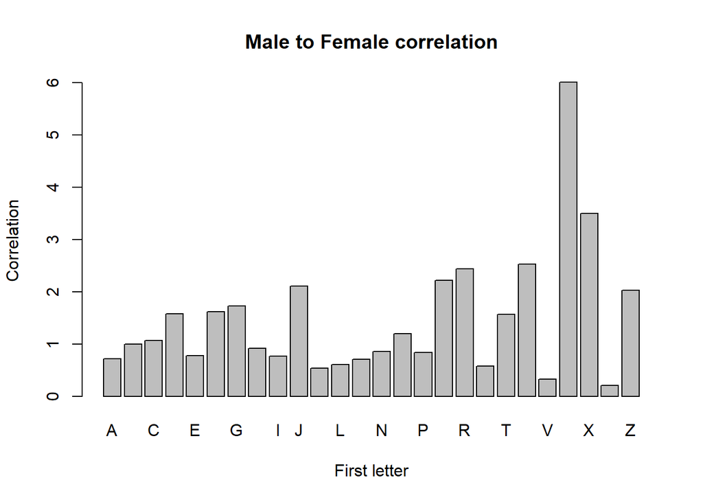

```r
barplot(data_cor$Correlation,
        names.arg = data_cor$Names,
        xlab = "First letter",
        ylab = "Correlation",
        main = "Male to Female correlation")
```

## Выводы 1. Имена на букву U — самые нераспространённые. 2. Чаще всего в USA имена мальчиков начинаются на букву J, а девочек — на M. 3. Имена на A,B,C,D,E в среднем распространены как у мальчиков, так и у девочек. 4. Если говорить об отношениях: 4.1. Больше всего мальчиков на девочку приходится на букву W: 6:1 4.2. Девочек на мальчика — на букву Y: 5:1.

```r
data_by_year <- data|>
  group_by(Year)|>
  summarise(Number = sum(Number))
```

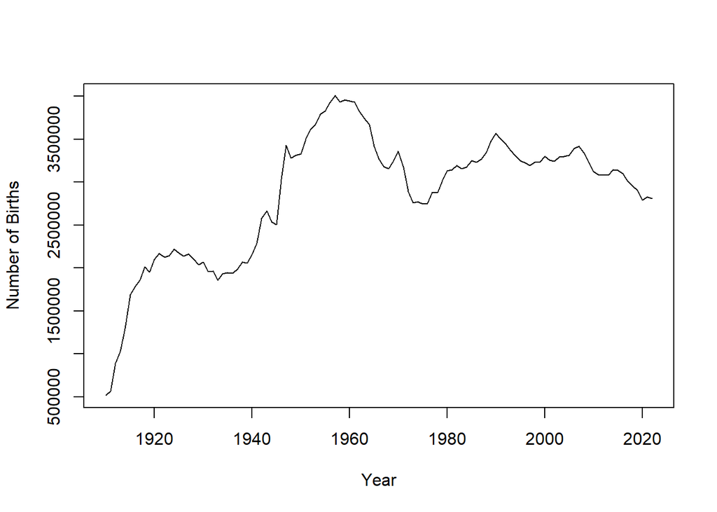

```r
plot(data_by_year$Year, data_by_year$Number, type="l",
     xlab = "Year", ylab = "Number of Births")
```

```r
summary(data_by_year$Number)
```

```
##    Min. 1st Qu.  Median    Mean 3rd Qu.    Max.
##  516312 2170952 3130853 2854681 3308783 4004570
```

```r
data_by_year$Year[which.max(data_by_year$Number)]
```

```
## [1] 1957
```

```r
data_by_state <- data |>
  group_by(State)|>
  summarise(Number = sum(Number))|>
  mutate(Ratio = Number/sum(Number))
```

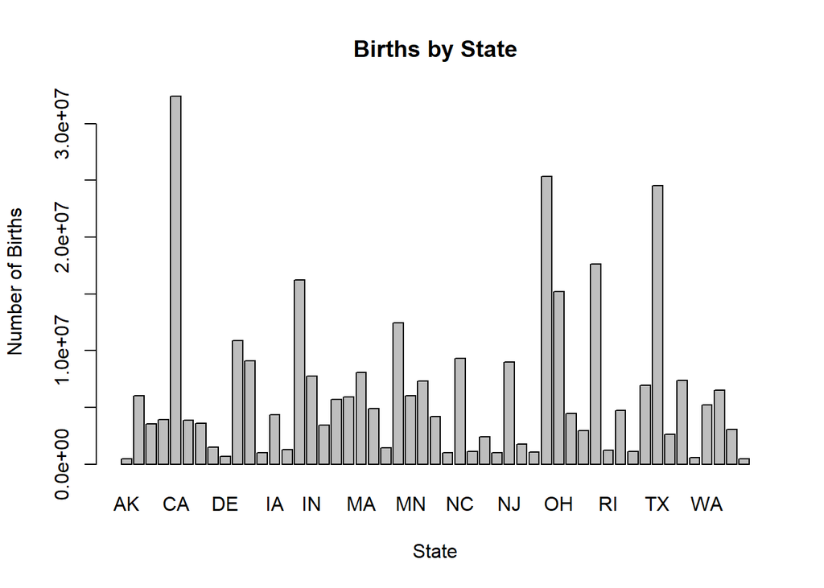

```r
barplot(data_by_state$Number,
        names.arg = data_by_state$State,
        xlab = "State",
        ylab = "Number of Births",
        main = "Births by State")
```

```r
data_by_state|>
  slice_max(order_by = Number, n = 10)
```

```
## # A tibble: 10 × 3
##    State   Number  Ratio
##    <chr>    <int>  <dbl>
##  1 CA    32408231 0.100
##  2 NY    25336581 0.0785
##  3 TX    24529507 0.0760
##  4 PA    17636136 0.0547
##  5 IL    16198309 0.0502
##  6 OH    15177474 0.0471
##  7 MI    12418229 0.0385
##  8 FL    10899712 0.0338
##  9 NC     9305202 0.0288
## 10 GA     9078939 0.0281
```

```r
data_by_state|>
  slice_min(order_by = Number, n = 10)
```

```
## # A tibble: 10 × 3
##    State  Number   Ratio
##    <chr>   <int>   <dbl>
##  1 WY     446101 0.00138
##  2 AK     453331 0.00141
##  3 VT     569784 0.00177
##  4 DE     668367 0.00207
##  5 MT    1000077 0.00310
##  6 HI    1012446 0.00314
##  7 NH    1027570 0.00319
##  8 NV    1051729 0.00326
##  9 SD    1110519 0.00344
## 10 ND    1121147 0.00348
```

```r
data_by_name <- data|>
  group_by(Name, Year)|>
  summarize(Number = sum(Number))
data_by_gender <- data|>
  group_by(Name, Gender)|>
  summarize(Number = sum(Number))
```

Мальчики

```r
top10_male <- data_by_gender|> as.data.frame()|>
  filter(Gender == "M")|>
  slice_max(order_by = Number, n = top10)|>
  select(Name)|> as.vector()
```

Рассмотрим 10 самых распространённых имён

```r
split_male <- data |>
  as.data.frame()|>
  filter(Gender == "M")|>
  group_by(Name, Year)|>
  summarize(Number = sum(Number))|>
  filter(Name %in% top10_male$Name)
```

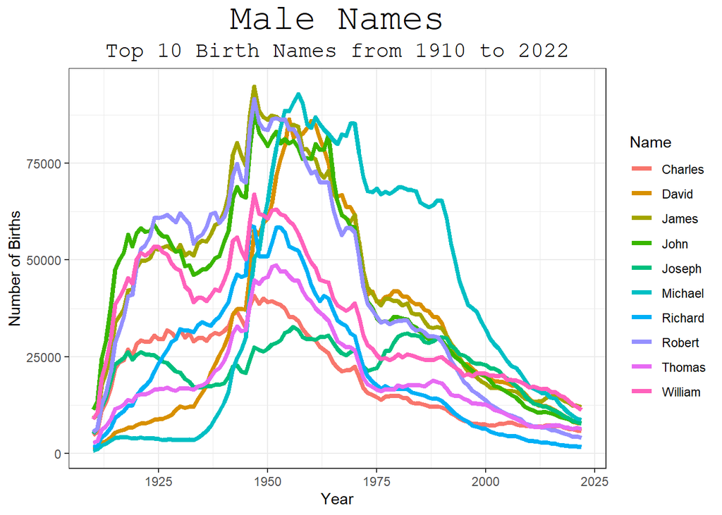

```r
theme_set(theme_bw())
ggplot(split_male, aes(x = Year, y = Number, color = Name))+
  geom_line(linewidth = 1.5) +
  labs(y = "Number of Births",
       title = "Male Names",
       subtitle = "Top 10 Birth Names from 1910 to 2022")+
  theme(plot.title = element_text(family = "mono", hjust = .5, size = 25),
        plot.subtitle = element_text(family = "mono", hjust = .5, size = 15))
```

```r
summary(split_male$Number)
```

```
##    Min. 1st Qu.  Median    Mean 3rd Qu.    Max.
##     795   14360   26447   32157   46666   94758
```

```r
top10_male_after_1975 <- data|> as.data.frame()|>
  filter(Gender == "M", Year >= 1975)|>
  group_by(Name)|>
  summarize(Number = sum(Number))|>
  slice_max(order_by = Number, n = top10)|>
  select(Name)|> as.vector()
```

```r
split_male_after_1975 <- data |>
  as.data.frame()|>
  filter(Gender == "M")|>
  group_by(Name, Year)|>
  summarize(Number = sum(Number))|>
  filter(Name %in% top10_male_after_1975$Name)
```

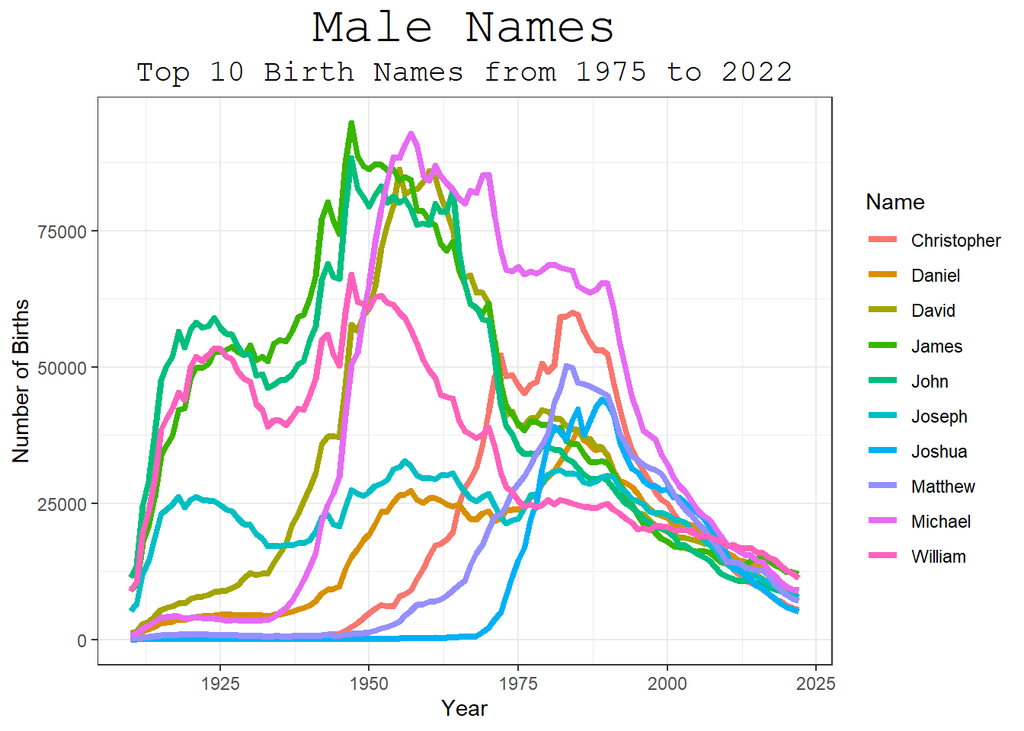

```r
theme_set(theme_bw())
ggplot(split_male_after_1975, aes(x = Year, y = Number, color = Name))+
  geom_line(linewidth = 1.5) +
  labs(y = "Number of Births",
       title = "Male Names",
       subtitle = "Top 10 Birth Names from 1975 to 2022")+
  theme(plot.title = element_text(family = "mono", hjust = .5, size = 25),
        plot.subtitle = element_text(family = "mono", hjust = .5, size = 15))
```

Девочки

```r
top10_female <- data_by_gender|> as.data.frame()|>
  filter(Gender == "F")|>
  slice_max(order_by = Number, n = top10)|>
  select(Name)|> as.vector()
```

```r
split_female <- data |>
  as.data.frame()|>
  filter(Gender == "F")|>
  group_by(Name, Year)|>
  summarize(Number = sum(Number))|>
  filter(Name %in% top10_female$Name)
```

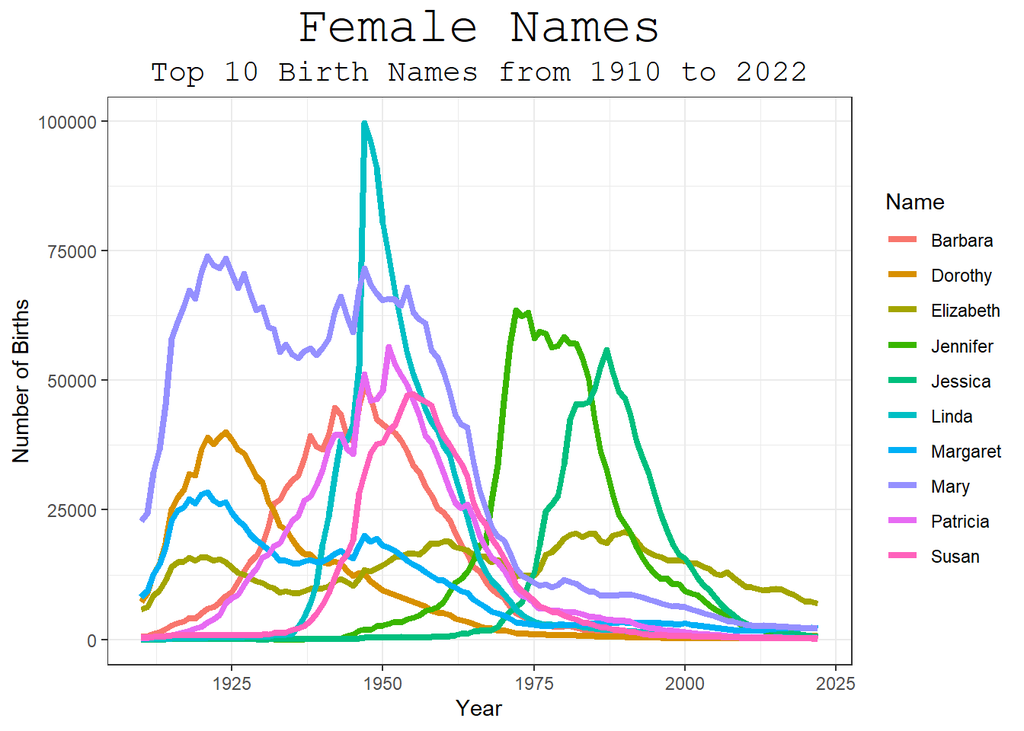

```r
ggplot(split_female, aes(x = Year, y = Number, color = Name))+
  geom_line(linewidth = 1.5) +
  labs(y = "Number of Births",
       title = "Female Names",
       subtitle = "Top 10 Birth Names from 1910 to 2022")+
  theme(plot.title = element_text(family = "mono", hjust = .5, size = 25),
        plot.subtitle = element_text(family = "mono", hjust = .5, size = 15))
```

```r
summary(split_female$Number)
```

```
##    Min. 1st Qu.  Median    Mean 3rd Qu.    Max.
##       5     958    6470   14102   18530   99693
```

## Интересный спад с 1975

А какие имена были популярны тогда?

```r
top10_female_after_1975 <- data|> as.data.frame()|>
  filter(Gender == "F", Year >= 1975)|>
  group_by(Name)|>
  summarize(Number = sum(Number))|>
  slice_max(order_by = Number, n = top10)|>
    select(Name)|> as.vector()
```

```r
split_female_after_1975 <- data |>
  as.data.frame()|>
  filter(Gender == "F", Year >= 1975)|>
  group_by(Name, Year)|>
  summarize(Number = sum(Number))|>
  filter(Name %in% top10_female_after_1975$Name)
```

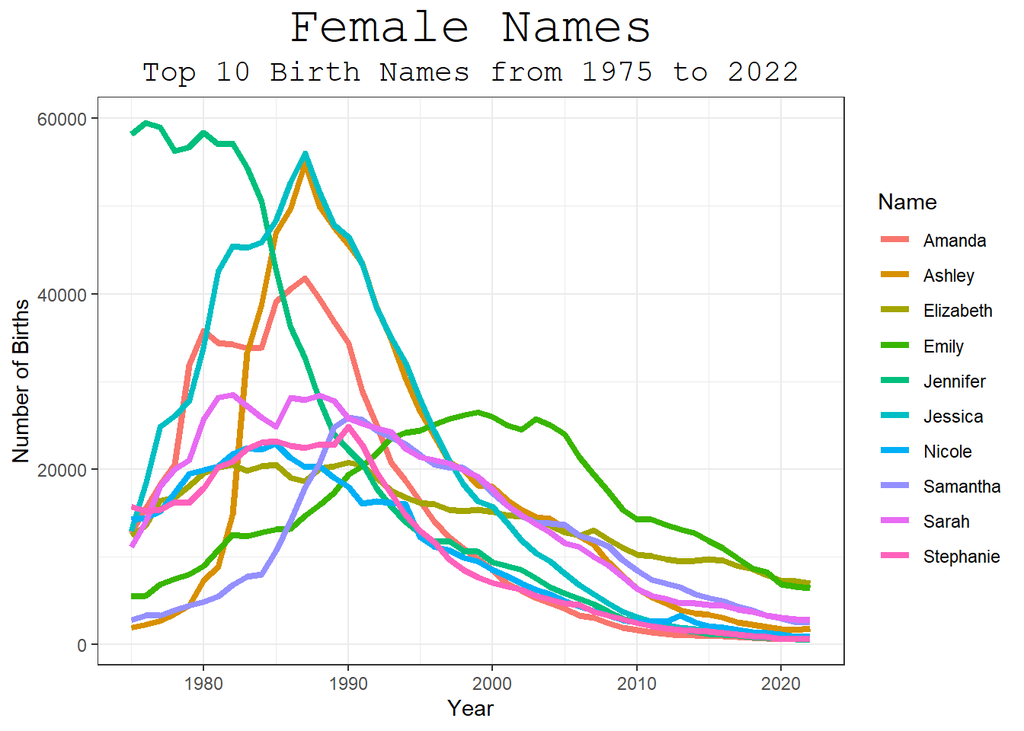

```r
theme_set(theme_bw())
ggplot(split_female_after_1975, aes(x = Year, y = Number, color = Name))+
  geom_line(linewidth = 1.5) +
  labs(y = "Number of Births",
       title = "Female Names",
       subtitle = "Top 10 Birth Names from 1975 to 2022")+
  theme(plot.title = element_text(family = "mono", hjust = .5, size = 25),
        plot.subtitle = element_text(family = "mono", hjust = .5, size = 15))
```

Рассмотрим самые популярные имена в период с 1948 по 1970 (пиковый момент):

```r
data_boom <- data|>as.data.frame()|>
  filter(Year <= 1970, Year >= 1948) |>
  group_by(Name, Gender) |>
  summarize(Number = sum(Number))|>
  arrange(desc(Number))
rmarkdown::paged_table(data_boom)
```

| Name | Gender | Number |
| --- | --- | --- |
| Michael | M | 1868380 |
| James | M | 1765681 |
| John | M | 1733787 |
| Robert | M | 1707648 |
| David | M | 1681807 |
| William | M | 1174979 |
| Mary | F | 1135507 |
| Richard | M | 1041668 |
| Linda | F | 985741 |
| Thomas | M | 897080 |

[output cut: 9178 more lines]

```r
summary(data_boom$Number)
```

```
##    Min. 1st Qu.  Median    Mean 3rd Qu.    Max.
##       5      11      69    9024     700 1868380
```

Выводы: 1. У девушек большая часть имён изменилась по популярности с 1975 в топе. 2. У мальчиков примерно половина.

```r
top10_female$Name
```

```
##  [1] "Mary"      "Patricia"  "Elizabeth" "Jennifer"  "Linda"     "Barbara"
##  [7] "Margaret"  "Susan"     "Dorothy"   "Jessica"
```

```r
top10_female_after_1975$Name
```

```
##  [1] "Jessica"   "Jennifer"  "Ashley"    "Emily"     "Sarah"     "Amanda"
##  [7] "Elizabeth" "Samantha"  "Stephanie" "Nicole"
```

```r
top10_male$Name
```

```
##  [1] "James"   "John"    "Robert"  "Michael" "William" "David"   "Joseph"
##  [8] "Richard" "Charles" "Thomas"
```

```r
top10_male_after_1975$Name
```

```
##  [1] "Michael"     "Christopher" "Matthew"     "Joshua"      "David"
##  [6] "James"       "Daniel"      "Joseph"      "John"        "William"
```

```r
data_2022 <- data|>
  as.data.frame()|>
  filter(Year == 2022)|>
  group_by(Name, Gender)|>
  summarize(Number = sum(Number))|>
  arrange(desc(Number))
rmarkdown::paged_table(data_2022)
```

| Name | Gender | Number |
| --- | --- | --- |
| Liam | M | 20456 |
| Noah | M | 18621 |
| Olivia | F | 16573 |
| Oliver | M | 15076 |
| Emma | F | 14435 |
| Charlotte | F | 12891 |
| Amelia | F | 12333 |
| Sophia | F | 12310 |
| James | M | 12028 |
| Elijah | M | 11979 |

[output cut: 9780 more lines]

```r
rmarkdown::paged_table(data_2022|>
                         filter(Gender == "M"))
```

| Name | Gender | Number |
| --- | --- | --- |
| Liam | M | 20456 |
| Noah | M | 18621 |
| Oliver | M | 15076 |
| James | M | 12028 |
| Elijah | M | 11979 |
| William | M | 11282 |
| Henry | M | 11221 |
| Lucas | M | 10909 |
| Benjamin | M | 10842 |
| Theodore | M | 10754 |

[output cut: 4335 more lines]

```r
rmarkdown::paged_table(data_2022|>
                         filter(Gender == "F"))
```

| Name | Gender | Number |
| --- | --- | --- |
| Olivia | F | 16573 |
| Emma | F | 14435 |
| Charlotte | F | 12891 |
| Amelia | F | 12333 |
| Sophia | F | 12310 |
| Isabella | F | 11662 |
| Ava | F | 11039 |
| Mia | F | 11018 |
| Evelyn | F | 9289 |
| Luna | F | 8922 |

[output cut: 5435 more lines]

### На будущее:

Можно взглянуть на изменение числа имён каждый год;

```r
data_name_uniqueness <- data |>
  group_by(Name, Year)|>
  summarize()|>
  group_by(Year)|>
  summarize(Name.number = n())
```

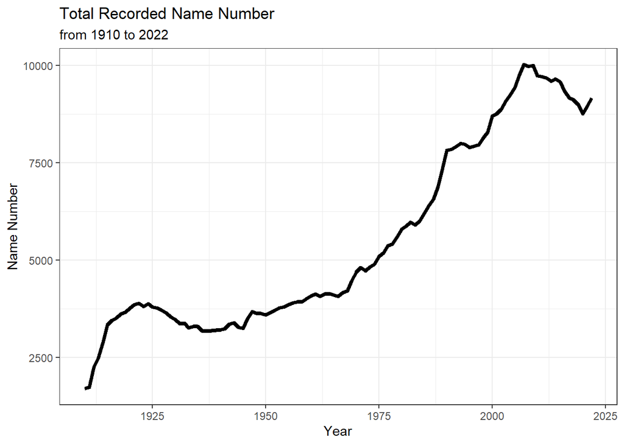

```r
ggplot(data_name_uniqueness, aes(x = Year, y = Name.number))+
  geom_line(linewidth = 1.5) +
  labs(y = "Name Number",
       title = "Total Recorded Name Number",
       subtitle = "from 1910 to 2022")+
  theme(plot.title = element_text(family = "mono", hjust = .5, size = 25),
        plot.subtitle = element_text(family = "mono", hjust = .5, size = 15))+
  theme_bw()
```

```r
1919 + which.max(data_name_uniqueness|>
            filter(Year >= 1920, Year <= 1950)|>
            select(Name.number)|>unlist()|>as.double())
```

```
## [1] 1922
```

```r
1919 + which.min(data_name_uniqueness|>
            filter(Year >= 1920, Year <= 1950)|>
            select(Name.number)|>unlist()|>as.double())
```

```
## [1] 1936
```

```r
data_1936_names <- data |>
  filter(Year == 1936)|>
  group_by(Name)|>
  summarize()|>pull(Name)

data_1922_names <- data|>
  filter(Year == 1922)|>
  group_by(Name)|>
  summarize()|>pull(Name)
```

```r
data_1936_names[!(data_1936_names %in% data_1922_names)]|>as.data.frame()|>
  rmarkdown::paged_table()
```

| data_1936_names[!(data_1936_names %in% data_1922_names)] |
| --- |
| Abigail |
| Abran |
| Adalberto |
| Adriana |
| Adrianne |
| Ailene |
| Alayne |
| Alejo |
| Aletta |
| Alexie |

[output cut: 568 more lines]

```r
data_1922_names[!(data_1922_names %in% data_1936_names)]|>as.data.frame()|>
  rmarkdown::paged_table()
```

| data_1922_names[!(data_1922_names %in% data_1936_names)] |
| --- |
| Abner |
| Acie |
| Adah |
| Adaline |
| Adel |
| Adelene |
| Adelino |
| Adelle |
| Adelyn |
| Adley |

[output cut: 1281 more lines]

```r
2003 + which.max(data_name_uniqueness|>
            filter(Year >= 2004)|>
            select(Name.number)|>unlist()|>as.double())
```

```
## [1] 2007
```

```r
2003 + which.min(data_name_uniqueness|>
            filter(Year >= 2004)|>
            select(Name.number)|>unlist()|>as.double())
```

```
## [1] 2020
```

```r
data_2007_names <- data |>
  filter(Year == 2007)|>
  group_by(Name)|>
  summarize()|>pull(Name)

data_2020_names <- data|>
  filter(Year == 2020)|>
  group_by(Name)|>
  summarize()|>pull(Name)
```

“Потерянные” имена (2007-2020):

```r
data_2007_names[!(data_2007_names %in% data_2020_names)]|>as.data.frame()|>
  rmarkdown::paged_table()
```

| data_2007_names[!(data_2007_names %in% data_2020_names)] |
| --- |
| Aadit |
| Aakash |
| Aaliyha |
| Aalyiah |
| Aanika |
| Aaren |
| Aaronjames |
| Aarushi |
| Aashi |
| Aashna |

[output cut: 3808 more lines]

и наоборот:

```r
data_2020_names[!(data_2020_names %in% data_2007_names)]|>as.data.frame()|>
  rmarkdown::paged_table()
```

| data_2020_names[!(data_2020_names %in% data_2007_names)] |
| --- |
| Aadhira |
| Aadhvik |
| Aadvik |
| Aadya |
| Aaira |
| Aairah |
| Aalam |
| Aalani |
| Aalayah |
| Aalia |

[output cut: 2545 more lines]